# EDA of 100-Year Storm Flood Risk from DataSF

Philippe Marchand

2026-05-04

According to the [DataSF description](https://data.sfgov.org/Public-Safety/100-Year-Storm-Flood-Risk-Zone-July-2022-/jzu3-4yxp/about_data), the “100-Year Storm Flood Risk Zone” dataset represents areas of at least the size of an average city block, which would be likely to experience at least six inches of flooding during a 100-year storm (i.e., a storm severity level with 1% chance of occurring each year). This is based on a model of storm water runoff by SFPUC.

```r
library(tidyverse)
library(sf)
library(raster)
library(mapview)

flood <- read_sf("100-Year Storm Flood Risk Zone (July 2022)_20260504")
flood
```

```
## Simple feature collection with 1 feature and 6 fields
## Geometry type: MULTIPOLYGON
## Dimension:     XY
## Bounding box:  xmin: -122.5102 ymin: 37.70864 xmax: -122.3856 ymax: 37.80851
## Geodetic CRS:  WGS 84
## # A tibble: 1 × 7
##   shape_leng shape_area date_data_ time_data_   date_dat_2 time_dat_2
##        <dbl>      <dbl> <date>     <chr>        <date>     <chr>
## 1    274986.  40087001. 2022-07-01 00:00:00.000 2022-08-12 00:00:00.000
## # ℹ 1 more variable: geometry <MULTIPOLYGON [°]>
```

The dataset itself is a single multipolygon feature with no associated data fields. As the map below shows, the largest flooding areas correspond to the historical Mission Creek and Islais Creek. Most other areas shown at risk of flood are smaller, spanning one or a few blocks.

For SafeHome, the area covered by that multipolygon could be shown as a layer, similar to the tsunami risk area in the current live site.

```r
mapview(flood)
```

[interactive chart not shown]

There is a different dataset on DataSF called “100-Year Storm Flood Elevations”.

```r
flood_elev <- read_sf("100-Year Storm Flood Elevations (December 2024)_20260504")
flood_elev
```

```
## Simple feature collection with 1450 features and 5 fields
## Geometry type: POLYGON
## Dimension:     XY
## Bounding box:  xmin: -122.5097 ymin: 37.70864 xmax: -122.3856 ymax: 37.80851
## Geodetic CRS:  WGS 84
## # A tibble: 1,450 × 6
##    contourmin contourmax orig_fid shape_leng shape_area
##         <dbl>      <dbl>    <dbl>      <dbl>      <dbl>
##  1        389        390        1       33.6       34.4
##  2        390        391        2      212.      3184.
##  3        390        391        2      276.      4419.
##  4        391        392        3      569.      5389.
##  5        391        392        3      330.      6151.
##  6        392        393        4       60.6      125.
##  7        392        393        4     1254.     43618.
##  8          3          4       14      412.      6138.
##  9         13         14      149     1241.     12964.
## 10        393        394        5      423.      2204.
## # ℹ 1,440 more rows
## # ℹ 1 more variable: geometry <POLYGON [°]>
```

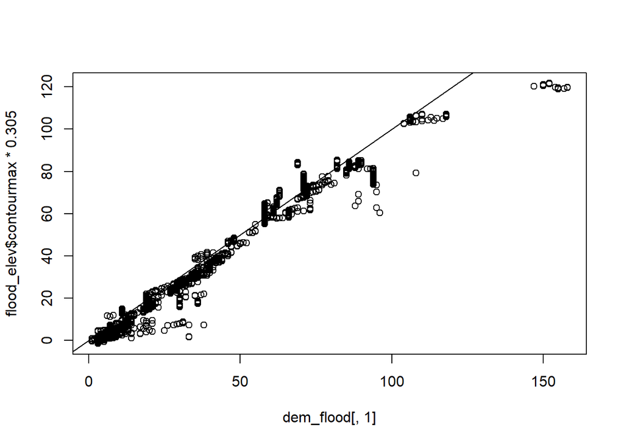

```r
# SF DEM: https://earthworks.stanford.edu/catalog/stanford-nh236hj3673
dem <- raster("DEM_30m/dem30m.tif")

dem_flood <- extract(dem, flood_elev, fun = min)
plot(dem_flood[,1], flood_elev$contourmax * 0.305)
# 0.305 converts feet to meters
abline(0,1)
```

Note that elevations are in meters for the DEM, rather than feet. The diagonal represents the identity line (1:1) on that graph.

Therefore, I would not recommend showing that information elevation, instead just display the simple layer above.